# Biostatistical Computing, PHC 6068

GitHub

Instructor: Zhiguang Huo (Caleb)  
Guest Speaker: Shangchen Song

Monday October 4, 2021

# Outline

- Git
  - Version control
  - Basic commands about Git
- GitHub
  - Introduction
  - GitHub commands
- Host R packages on GitHub

# Git

- Git is a distributed version-control system for tracking changes in source code during software development.
- It is designed for coordinating work among programmers
- It can be used to track changes in any set of files.

# Benefits of version control

- For yourself:
  - Keep complete history of changes, and rationale for all changes
  - Go back to a previous version of your code
  - Support multiple version of the same basic project
- Collaborative project:
  - Simplifies concurrent work and merging changes
  - You can backup your code remotely (on GitHub), which can be easily distributed

# Setting up the Git

- Install the Git
  - https://git-scm.com/book/en/v2/Getting-Started-Installing-Git
- Start Git
  - Windows: Git Bash
  - Mac: Terminal
  - Rstudio: there is a terminal window as well (handy for R)
- Set up a user.name and user.email (if this is your first time to use git)
  - You only need to do this once

```
git config --global user.name "Sam Smith"
git config --global user.email sam@example.com
```

- Check the settings

```
git config --list
```

# Git basics

- The three states

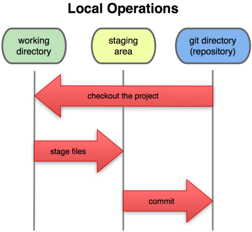

- The Git directory (repository)
  - stores the metadata and object database for your project.
  - what is copied when you clone a repository from another computer.
  - offers snapshots (commits) of your project history. You can go back to them later.
- The working directory
  - one snapshot where you are currently working with
  - a single checkout of one version of the project.
  - you can usually pull from the Git directory to update it.
- The staging area
  - stores information about what will go into your next commit. The list of changed files will be committed to repository
  - sometimes referred as the index
  - intermediate step between the working directory and the Git directory

# Git workflow

- You modify files in your working directory.
- You stage the files, adding snapshots of them to your staging area (index).

```
git add XXX
```

- You do a commit, which takes the files in the staging area as snapshots to the Git directory.

```
git commit -m "your message"
```

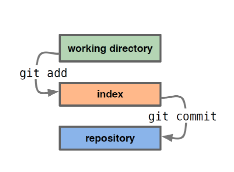

# Example to make change in git repository (use R codes as example)

- Initialize a R package (macOS/Linux)

```
WD <- '~/Desktop'
setwd(WD)

usethis::create_package("GatorPKG", open = FALSE) ## open = FALSE will prevent R open a new R studio session.
WD2 <- '~/Desktop/GatorPKG'
setwd(WD2)
```

- Initialize a R package (Windows)

```
WD <- 'C:/Users/ss/Desktop/'
setwd(WD)
usethis::create_package("GatorPKG", open = FALSE) ## open = FALSE will prevent R open a new R studio session.
```

- Put in f.R in the R folder

```
##' Add up two numbers (Description)
##'
##' We want to add up two numbers, blalala... (Details)
##' @title add two numbers
##' @param x first number
##' @param y second number
##' @return sum of two numbers
##' @author Caleb
##' @export
##' @examples
##' f(1,2)
f <- function(x, y) x + y
```

# Example to make change in git repository (git part)

- Initialize git (in bash)

```
cd ~/Desktop/GatorPKG
git init
```

- Check the status of files in the working directory

```
git status
```

- Stage your changes

```
git add -A ## -A stage all your files
git status
```

- Commit your changes

```
git commit -m "first commit"
git status
```

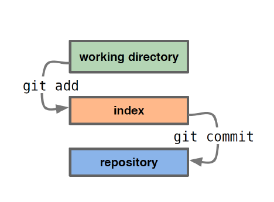

# git status

- Tells what Git thinks is going on
- Do this frequently!
1. before staging your workspace

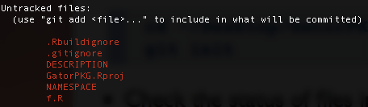

2. after staging your workspace, before committing

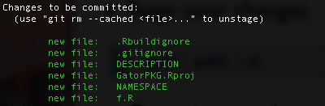

# git add

- add one file

```
git add newFile
```

- add multiple files

```
git add newFile1 newFile2 newFile3
```

- add all

```
git add -A
```

# git commit

- committing makes a snapshot of everything that has been staged in your repository
- a short message is necessary

```
git commit -m "any message you want to make here"
```

- The message is required and will be helpful for the future you and your teammates
- If you don’t type in a message, it usually will return an error or an editor (usually vi) will be opened for you to enter the message. Vi is hard to use for beginners. See https://kb.iu.edu/d/afcz about how to quit vi, just in case.
- After you commit your changes to git, it will create a commit object
- You can view all commit objects by

```
git log
```

# Other files in the repository

```
ls -a ## list all files, including hidden ones
```

- .git: containing commit histories
- .gitignore: containing format of files that you want git to ignore
  - e.g., add the following in .gitignore

  ```
  GatorPKG.Rproj
  .DS_Store
  */.DS_Store
  ```

  - .DS_Store are some undesired files from Mac
- .Rbuildignore: files that you want to ignore when building the R package
- License: do not need to be specified, if it is already in the DESCRIPTION

# More on git

- Git only saves the changes from the previous commit, won’t waste space
- Just make commits often

# So far, local version control

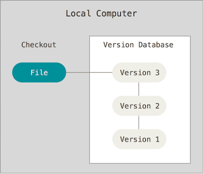

# Distributed version control

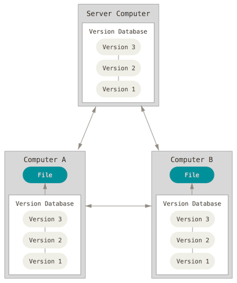

# Distributed version control

- GitHub
  - GitHub provides free repositories, given that you make your project open.
  - GitHub provides inidivual accounts, and organizational accounts.
  - Academic users (you need to apply) can have free private repositories. https://education.github.com/students
  - Usually 1Gb limit per repository.
  - https://github.com
  - When you prepare R packages for CRAN or bioconductor, you will need GitHub
- BitBucket
  - Similar to GitHub, but provide free private repositories.
- GitLab

# Connect the local repository with GitHub

- Benefit
  - You can work anywhere with any computer, as long as you can pull/fetch your project from the remote.
  - You and your teammates can work on the same project from the same remote.

# Set up GitHub and connect with your local repository (1)

- Sign up/in GitHub
- Create a new repository on GitHub (GatorPKG).

[figure not shown]

# Set up GitHub and connect with your local repository (2)

- clone to your local computer (e.g., desktop)

[figure not shown]

```
cd "~/Desktop"
git clone https://github.com/lovestat/GatorPKG.git
```

**Make sure to use this way to initialize your repository, in order to connect to GitHub**

# Set up GitHub and connect with your local repository (3)

Put your code in the GatorPKG package

- You should have at least the following files or folders:
  - DESCRIPTION
  - NAMESPACE
  - /R

# Set up GitHub and connect with your local repository (4)

- In R, to add the documentation for f.R

```
devtools::document()
```

- At the directory of your local repository (e.g., ~/Desktop/GatorPKG), do the following in the terminal

```
git add -A
git commit -m "1st R pacakge"
git log
```

You will see a SHA1 number (Secure Hash Algorithm 1), this is the access number of a commit object

- Push your changes in local repository to GitHub

```
git push
```

- Refresh your GitHub page to see if the changes are made on GitHub
- Install the package from GitHub in R

```
devtools::install_github("lovestat/GatorPKG")
library(GatorPKG)
f(1,2)
?f
```

# Your turn

Goals:

- make an R package on your GitHub repository
- install this package by devtools::install_github

# Add README.md on GitHub

- md represents mark down
- .md is very similar to .Rmd
  - except it won’t evaluate R code
- Below is an toy example of README.md

```
# testGatorPKG
This is a fancy R package

## how to install the R package
`devtools::install_github("lovestat/GatorPKG")`

## example
`f(1,2)`
```

- You can add it locally, and push back to GitHub, just like f.R
- Or you can directly edit on the remote, then fetch/pull to the local repository

# More on the remote

Two ways to get your PC updated with the latest remote repository

- If you already have a copy of the remote repository on your computer
  - git fetch
  - git pull
- If you don’t have a copy of the remote repository on your computer
  - git clone

# Keep updated with the remote

- Update your local repository

```
git fetch
```

- Update your workspace

```
git pull
```

# Clone an existing remote repository to your local PC

[figure not shown]

```
git clone https://github.com/cran/mclust.git
```

After some changes of this package

- If you are the owner/team member of the origin remote repository, you are able to push back.
- If you are not the owner, you won’t be able to push back

# Fork a repository on your GitHub account

- Click on Fork, the repository will be copied to your GitHub account

[figure not shown]

- Then you can do anything you want on the forked repository, under their license

# Whole picture for Git operations

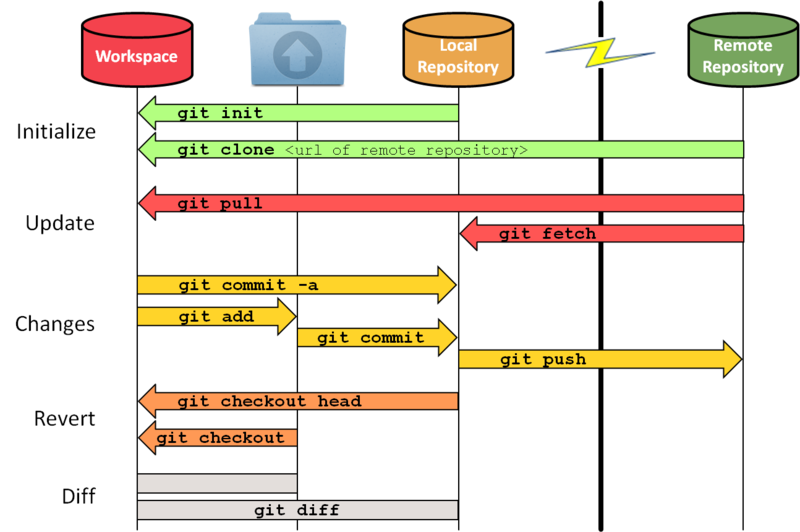

- Have talked about initialize, update, changes
- Will talk about **branching** before revert and diff

# Git branches

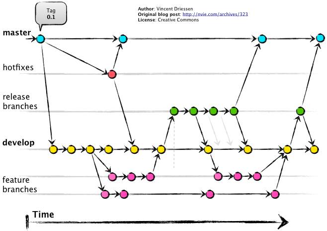

- **master**
- hotfixes
- release branches
- **develop**
- feature branches

# Basic commands for Branching

- By default, we are on the main/master branch
  - Now we want to create some new features on the develop/feature branch
- Create a new branch and switch to it:

```
git checkout -b <branchname>
```

- Switch from one branch to another:

```
git checkout <branchname>
```

- List all branches and tell where am I:

```
git branch
```

- Delete one branch

```
git branch -d <branchname>
```

- Push the branch to the remote

```
git push origin <branchname>
```

# Exercise for creating an additional branch

- in git

```
git checkout -b vignette
```

- in R

```
usethis::use_vignette("GatorPKG")
```

- in git

```
git add -A
git commit -m "include vignette"
```

- Check all available branches (your current branch has a * on it)

```
git branch
```

- Go back to main

```
git checkout main
```

# Git revert

Go back to the previous snapshot by SHA1 number

- If you want to temporarily go back to it
  - This will detach your HEAD, that is, leave you with no branch checked out

  ```
  git checkout f0d8506
  git branch
  ```

- Or if you want to make commits while you’re there, go ahead and make a new branch while you’re at it:

```
git checkout -b old-state f0d8506
git branch
```

- To go back to where you were, just check out the branch you were on again.

```
git checkout main
```

# Git merge (when there are no conflicts)

- keep merging history
  - If you want to merge branch B (vignette) into branch A (main)
  - Go to branch A (main)
  - merge –no-ff

```
git checkout main
git merge --no-ff vignette
git log
```

- VI save and quit: https://linuxize.com/post/how-to-save-file-in-vim-quit-editor/

# Compare with another commit object

- compare all changes in the working directory with the last commit

```
git diff
```

- compare the change for a specific file in the working directory with the last commit

```
git diff --base <filename>
```

- compare two commits

```
git diff aSHA1 bSHA1
```

- compare two branches

```
git diff <sourcebranch> <targetbranch>
```

# Set alias for github command

- my favorite colorful logs

```
git config --global alias.lg "log --color --graph --pretty=format:'%Cred%h%Creset -%C(yellow)%d%Creset %s %Cgreen(%cr) %C(bold blue)<%an>%Creset' --abbrev-commit --"
```

- Then do

```
git lg
```

# Add R CMD check on GitHub

- Run this following code will set up the GitHub Action, a tool automates software workflows, for R CMD check.
- No need to run R CMD check on your computer.
- It will automatically run R CMD check for each commits pushed on GitHub.
- In details, this workflow runs R CMD check via the rcmdcheck package on the three major operating systems (linux, macOS, and Windows) on the latest release of R and on R-devel. This workflow is appropriate for a package that is (or will hopefully be) on CRAN or Bioconductor.

```
usethis::use_github_action_check_standard()
```

[figure not shown]

# Add README badges/icons for your package

- The badges can be informative regarding your package status

[figure not shown]

- Run the following code in your package project and do as the output suggests

```
usethis::use_cran_badge()
usethis::use_lifecycle_badge("stable")
use_github_actions_badge(name = "R-CMD-check", repo_spec = NULL)
```

# Build A package website for your package (1)

- Build website like the following
- This might need GitHub Pages for your account. Very easy to setup https://pages.github.com/

[figure not shown]

```
usethis::use_pkgdown()
pkgdown::build_site()
usethis::use_github_action("pkgdown")
```

- Push it

```
git add -A
git commit -m "add pkgdown"
git push
```

- `usethis::use_github_action("pkgdown")` could take a few minutes to complete.
- After `usethis::use_github_action("pkgdown")` is finished, there would be additional branch called `gh-pages`.

# Build A package website for your package (2)

- Open `Settings` in the repository GatorPKG page
- Select `Pages` in the sidebar
- Under `Source` section, select `Branch: gh-pages` and `/(root)`. Then hit Save
- Wait for a few minutes, then the package website will be published with above URL. The URL can be changed in settings.

[figure not shown]

# Display html on github

- the html file won’t automatically show up in a webpage
- need the following trick
  - http://htmlpreview.github.io/? + the html location
  - e.g., http://htmlpreview.github.io/?https://github.com/Caleb-Huo/AWFisher/blob/master/vignettes/AWFisher.html

# Use GitHub as a raw code repository

- Upload an R script to your GitHub repository https://github.com/lovestat/misc-code/blob/main/emojiFace.R
- Open the R script and click the Raw button
- Copy the raw link in the address bar
- Feed it into the `source()` function in your RStudio

```
address <- "https://raw.githubusercontent.com/lovestat/misc-code/main/emojiFace.R"
source(address, echo = T)
```

# Reference:

- GitHub pro
  - https://git-scm.com/book/en/v2
- Summary of Git command
  - https://confluence.atlassian.com/bitbucketserver/basic-git-commands-776639767.html
- Many contents are from the following resources:
  - https://confluence.atlassian.com/bitbucketserver/basic-git-commands-776639767.html
  - https://www.ifi.uzh.ch/dam/jcr:ff780599-d5e2-4d05-b923-1c333cbf2842/A%20Tutorial%20for%20GitHub.pdf
  - https://git-scm.com/book/en/v1/Getting-Started-Git-Basics
  - https://happygitwithr.com/rstudio-see-git.html